# INN Hotels Project

## Context

A significant number of hotel bookings are called-off due to cancellations or no-shows. The typical reasons for cancellations include change of plans, scheduling conflicts, etc. This is often made easier by the option to do so free of charge or preferably at a low cost which is beneficial to hotel guests but it is a less desirable and possibly revenue-diminishing factor for hotels to deal with. Such losses are particularly high on last-minute cancellations.

The new technologies involving online booking channels have dramatically changed customers’ booking possibilities and behavior. This adds a further dimension to the challenge of how hotels handle cancellations, which are no longer limited to traditional booking and guest characteristics.

The cancellation of bookings impact a hotel on various fronts:

- Loss of resources (revenue) when the hotel cannot resell the room.
- Additional costs of distribution channels by increasing commissions or paying for publicity to help sell these rooms.
- Lowering prices last minute, so the hotel can resell a room, resulting in reducing the profit margin.
- Human resources to make arrangements for the guests.

## Objective

The increasing number of cancellations calls for a Machine Learning based solution that can help in predicting which booking is likely to be canceled. INN Hotels Group has a chain of hotels in Portugal, they are facing problems with the high number of booking cancellations and have reached out to your firm for data-driven solutions. You as a data scientist have to analyze the data provided to find which factors have a high influence on booking cancellations, build a predictive model that can predict which booking is going to be canceled in advance, and help in formulating profitable policies for cancellations and refunds.

## Data Description

The data contains the different attributes of customers' booking details. The detailed data dictionary is given below.

**Data Dictionary**

- Booking_ID: unique identifier of each booking
- no_of_adults: Number of adults
- no_of_children: Number of Children
- no_of_weekend_nights: Number of weekend nights (Saturday or Sunday) the guest stayed or booked to stay at the hotel
- no_of_week_nights: Number of week nights (Monday to Friday) the guest stayed or booked to stay at the hotel
- type_of_meal_plan: Type of meal plan booked by the customer:
  - Not Selected – No meal plan selected
  - Meal Plan 1 – Breakfast
  - Meal Plan 2 – Half board (breakfast and one other meal)
  - Meal Plan 3 – Full board (breakfast, lunch, and dinner)
- required_car_parking_space: Does the customer require a car parking space? (0 - No, 1- Yes)
- room_type_reserved: Type of room reserved by the customer. The values are ciphered (encoded) by INN Hotels.
- lead_time: Number of days between the date of booking and the arrival date
- arrival_year: Year of arrival date
- arrival_month: Month of arrival date
- arrival_date: Date of the month
- market_segment_type: Market segment designation.
- repeated_guest: Is the customer a repeated guest? (0 - No, 1- Yes)
- no_of_previous_cancellations: Number of previous bookings that were canceled by the customer prior to the current booking
- no_of_previous_bookings_not_canceled: Number of previous bookings not canceled by the customer prior to the current booking
- avg_price_per_room: Average price per day of the reservation; prices of the rooms are dynamic. (in euros)
- no_of_special_requests: Total number of special requests made by the customer (e.g. high floor, view from the room, etc)
- booking_status: Flag indicating if the booking was canceled or not.

## Importing necessary libraries and data

```python
import warnings
warnings.filterwarnings("ignore")

from statsmodels.tools.sm_exceptions import ConvergenceWarning
warnings.simplefilter("ignore", ConvergenceWarning)

import numpy as np
import pandas as pd
import matplotlib.pyplot as plt
import seaborn as sns

from sklearn.model_selection import train_test_split
from sklearn.tree import DecisionTreeClassifier
from sklearn import tree
from sklearn.model_selection import GridSearchCV
from sklearn import metrics

import statsmodels.stats.api as sms
from statsmodels.stats.outliers_influence import variance_inflation_factor
import statsmodels.api as sm
from statsmodels.tools.tools import add_constant

from sklearn.metrics import(
    f1_score,
    accuracy_score,
    recall_score,
    precision_score,
    confusion_matrix,
    roc_auc_score,
    plot_confusion_matrix,
    precision_recall_curve,
    roc_curve,
    make_scorer,
)
```

## Data Overview

- Observations
- Sanity checks

```python
data = pd.read_csv("INNHotelsGroup.csv")
df = data.copy()
```

```python
# Observations
df.head()
```

|  | Booking_ID | no_of_adults | no_of_children | no_of_weekend_nights | no_of_week_nights | type_of_meal_plan | required_car_parking_space | room_type_reserved | lead_time | arrival_year | arrival_month | arrival_date | market_segment_type | repeated_guest | no_of_previous_cancellations | no_of_previous_bookings_not_canceled | avg_price_per_room | no_of_special_requests | booking_status |
| --- | --- | --- | --- | --- | --- | --- | --- | --- | --- | --- | --- | --- | --- | --- | --- | --- | --- | --- | --- |
| 0 | INN00001 | 2 | 0 | 1 | 2 | Meal Plan 1 | 0 | Room_Type 1 | 224 | 2017 | 10 | 2 | Offline | 0 | 0 | 0 | 65.00 | 0 | Not_Canceled |
| 1 | INN00002 | 2 | 0 | 2 | 3 | Not Selected | 0 | Room_Type 1 | 5 | 2018 | 11 | 6 | Online | 0 | 0 | 0 | 106.68 | 1 | Not_Canceled |
| 2 | INN00003 | 1 | 0 | 2 | 1 | Meal Plan 1 | 0 | Room_Type 1 | 1 | 2018 | 2 | 28 | Online | 0 | 0 | 0 | 60.00 | 0 | Canceled |
| 3 | INN00004 | 2 | 0 | 0 | 2 | Meal Plan 1 | 0 | Room_Type 1 | 211 | 2018 | 5 | 20 | Online | 0 | 0 | 0 | 100.00 | 0 | Canceled |
| 4 | INN00005 | 2 | 0 | 1 | 1 | Not Selected | 0 | Room_Type 1 | 48 | 2018 | 4 | 11 | Online | 0 | 0 | 0 | 94.50 | 0 | Canceled |

```python
df.tail()
```

|  | Booking_ID | no_of_adults | no_of_children | no_of_weekend_nights | no_of_week_nights | type_of_meal_plan | required_car_parking_space | room_type_reserved | lead_time | arrival_year | arrival_month | arrival_date | market_segment_type | repeated_guest | no_of_previous_cancellations | no_of_previous_bookings_not_canceled | avg_price_per_room | no_of_special_requests | booking_status |
| --- | --- | --- | --- | --- | --- | --- | --- | --- | --- | --- | --- | --- | --- | --- | --- | --- | --- | --- | --- |
| 36270 | INN36271 | 3 | 0 | 2 | 6 | Meal Plan 1 | 0 | Room_Type 4 | 85 | 2018 | 8 | 3 | Online | 0 | 0 | 0 | 167.80 | 1 | Not_Canceled |
| 36271 | INN36272 | 2 | 0 | 1 | 3 | Meal Plan 1 | 0 | Room_Type 1 | 228 | 2018 | 10 | 17 | Online | 0 | 0 | 0 | 90.95 | 2 | Canceled |
| 36272 | INN36273 | 2 | 0 | 2 | 6 | Meal Plan 1 | 0 | Room_Type 1 | 148 | 2018 | 7 | 1 | Online | 0 | 0 | 0 | 98.39 | 2 | Not_Canceled |
| 36273 | INN36274 | 2 | 0 | 0 | 3 | Not Selected | 0 | Room_Type 1 | 63 | 2018 | 4 | 21 | Online | 0 | 0 | 0 | 94.50 | 0 | Canceled |
| 36274 | INN36275 | 2 | 0 | 1 | 2 | Meal Plan 1 | 0 | Room_Type 1 | 207 | 2018 | 12 | 30 | Offline | 0 | 0 | 0 | 161.67 | 0 | Not_Canceled |

```python
df.shape # Total of 36275 rows with 19 columns
```

```
(36275, 19)
```

```python
df.info()
# Data-type includes 13 int, 1 float, 5 object (including Booking_ID)
```

```
<class 'pandas.core.frame.DataFrame'>
RangeIndex: 36275 entries, 0 to 36274
Data columns (total 19 columns):
 #   Column                                Non-Null Count  Dtype
---  ------                                --------------  -----
 0   Booking_ID                            36275 non-null  object
 1   no_of_adults                          36275 non-null  int64
 2   no_of_children                        36275 non-null  int64
 3   no_of_weekend_nights                  36275 non-null  int64
 4   no_of_week_nights                     36275 non-null  int64
 5   type_of_meal_plan                     36275 non-null  object
 6   required_car_parking_space            36275 non-null  int64
 7   room_type_reserved                    36275 non-null  object
 8   lead_time                             36275 non-null  int64
 9   arrival_year                          36275 non-null  int64
 10  arrival_month                         36275 non-null  int64
 11  arrival_date                          36275 non-null  int64
 12  market_segment_type                   36275 non-null  object
 13  repeated_guest                        36275 non-null  int64
 14  no_of_previous_cancellations          36275 non-null  int64
 15  no_of_previous_bookings_not_canceled  36275 non-null  int64
 16  avg_price_per_room                    36275 non-null  float64
 17  no_of_special_requests                36275 non-null  int64
 18  booking_status                        36275 non-null  object
dtypes: float64(1), int64(13), object(5)
memory usage: 5.3+ MB
```

```python
df.describe(include="all").T
# including numerical and categorical variables
```

|  | count | unique | top | freq | mean | std | min | 25% | 50% | 75% | max |
| --- | --- | --- | --- | --- | --- | --- | --- | --- | --- | --- | --- |
| Booking_ID | 36275 | 36275 | INN00001 | 1 | NaN | NaN | NaN | NaN | NaN | NaN | NaN |
| no_of_adults | 36275.0 | NaN | NaN | NaN | 1.844962 | 0.518715 | 0.0 | 2.0 | 2.0 | 2.0 | 4.0 |
| no_of_children | 36275.0 | NaN | NaN | NaN | 0.105279 | 0.402648 | 0.0 | 0.0 | 0.0 | 0.0 | 10.0 |
| no_of_weekend_nights | 36275.0 | NaN | NaN | NaN | 0.810724 | 0.870644 | 0.0 | 0.0 | 1.0 | 2.0 | 7.0 |
| no_of_week_nights | 36275.0 | NaN | NaN | NaN | 2.2043 | 1.410905 | 0.0 | 1.0 | 2.0 | 3.0 | 17.0 |
| type_of_meal_plan | 36275 | 4 | Meal Plan 1 | 27835 | NaN | NaN | NaN | NaN | NaN | NaN | NaN |
| required_car_parking_space | 36275.0 | NaN | NaN | NaN | 0.030986 | 0.173281 | 0.0 | 0.0 | 0.0 | 0.0 | 1.0 |
| room_type_reserved | 36275 | 7 | Room_Type 1 | 28130 | NaN | NaN | NaN | NaN | NaN | NaN | NaN |
| lead_time | 36275.0 | NaN | NaN | NaN | 85.232557 | 85.930817 | 0.0 | 17.0 | 57.0 | 126.0 | 443.0 |
| arrival_year | 36275.0 | NaN | NaN | NaN | 2017.820427 | 0.383836 | 2017.0 | 2018.0 | 2018.0 | 2018.0 | 2018.0 |
| arrival_month | 36275.0 | NaN | NaN | NaN | 7.423653 | 3.069894 | 1.0 | 5.0 | 8.0 | 10.0 | 12.0 |
| arrival_date | 36275.0 | NaN | NaN | NaN | 15.596995 | 8.740447 | 1.0 | 8.0 | 16.0 | 23.0 | 31.0 |
| market_segment_type | 36275 | 5 | Online | 23214 | NaN | NaN | NaN | NaN | NaN | NaN | NaN |
| repeated_guest | 36275.0 | NaN | NaN | NaN | 0.025637 | 0.158053 | 0.0 | 0.0 | 0.0 | 0.0 | 1.0 |
| no_of_previous_cancellations | 36275.0 | NaN | NaN | NaN | 0.023349 | 0.368331 | 0.0 | 0.0 | 0.0 | 0.0 | 13.0 |
| no_of_previous_bookings_not_canceled | 36275.0 | NaN | NaN | NaN | 0.153411 | 1.754171 | 0.0 | 0.0 | 0.0 | 0.0 | 58.0 |
| avg_price_per_room | 36275.0 | NaN | NaN | NaN | 103.423539 | 35.089424 | 0.0 | 80.3 | 99.45 | 120.0 | 540.0 |
| no_of_special_requests | 36275.0 | NaN | NaN | NaN | 0.619655 | 0.786236 | 0.0 | 0.0 | 0.0 | 1.0 | 5.0 |
| booking_status | 36275 | 2 | Not_Canceled | 24390 | NaN | NaN | NaN | NaN | NaN | NaN | NaN |

**Statistical summary of Numerical Variables**

- no_of_adults(numercial-discrete)= Count of number of adults range from 0 to 4
- no_of_children(numerical-discrete)= Count of number of children range from 0 to 10
- no_of_weekend_nights(numerical-discrete)= Number of weekend nights the guest stayed or booked to stay at the hotel ranges from 0 to 7
- no_of_week_nights(numerical-discrete)= Number of week nights (Monday to Friday) the guest stayed, ranges from 0 to 17 days
- type_of_meal_plan(categorical)= Meal Plan 1, is the most type of meal plan booked by customers
- required_car_parking_space(categorical/into numerical)= Both no, yes for customers requiring car parking space
- room_type_reserved(categorical)= Room Type 1 is reserved the most by customers
- lead_time(numerical-discrete)= Days between book - arrival date ranges from 0 to 443days . On average, 85 days.
- arrival_year(categorical)= Year of arrival ranges from 2017 to 2018
- arrival_month(categorical)= Month of arrival ranges from 1 (Jan) to 12 (Dec)
- arrival_date(categorical)= Date of month ranges from 1 to 31st

  > **Data from 2017 (Jan-Dec) to 2018 (Jan-Dec)**
- market_segment_type(categorical)= Market segment type has 5 types, with 'Online' the most count
- repeated_guest(categorical)= Two types of customers, yes or no of repeated guests
- no_of_previous_cancellations(numerical-discrete)= Number of previous bookings ranges from 0 to 13 bookings
- no_of_previous_bookings_not_canceled(numerical-discrete)= Number of previous bookings not cancelled ranges from 0 to 58 bookings
- avg_price_per_room(numerical-continuous)= average price per day of reservation ranges from 0 to 540 euros (wonder, why 0?)
- no_of_special_requests(numerical-discrete)= Total number of special requests range from 0 to 5
- booking_status(categorical)= 'Not canceled' has more counts than 'canceled'

```python
# let's look at duplications
df.duplicated().value_counts()
# There are no duplications
```

```
False    36275
dtype: int64
```

```python
# let's check for missing values
df.isnull().sum()
# There are no missing values
```

```
Booking_ID                              0
no_of_adults                            0
no_of_children                          0
no_of_weekend_nights                    0
no_of_week_nights                       0
type_of_meal_plan                       0
required_car_parking_space              0
room_type_reserved                      0
lead_time                               0
arrival_year                            0
arrival_month                           0
arrival_date                            0
market_segment_type                     0
repeated_guest                          0
no_of_previous_cancellations            0
no_of_previous_bookings_not_canceled    0
avg_price_per_room                      0
no_of_special_requests                  0
booking_status                          0
dtype: int64
```

```python
# let's drop Booking_ID
df.drop(["Booking_ID"], axis=1)
```

|  | no_of_adults | no_of_children | no_of_weekend_nights | no_of_week_nights | type_of_meal_plan | required_car_parking_space | room_type_reserved | lead_time | arrival_year | arrival_month | arrival_date | market_segment_type | repeated_guest | no_of_previous_cancellations | no_of_previous_bookings_not_canceled | avg_price_per_room | no_of_special_requests | booking_status |
| --- | --- | --- | --- | --- | --- | --- | --- | --- | --- | --- | --- | --- | --- | --- | --- | --- | --- | --- |
| 0 | 2 | 0 | 1 | 2 | Meal Plan 1 | 0 | Room_Type 1 | 224 | 2017 | 10 | 2 | Offline | 0 | 0 | 0 | 65.00 | 0 | Not_Canceled |
| 1 | 2 | 0 | 2 | 3 | Not Selected | 0 | Room_Type 1 | 5 | 2018 | 11 | 6 | Online | 0 | 0 | 0 | 106.68 | 1 | Not_Canceled |
| 2 | 1 | 0 | 2 | 1 | Meal Plan 1 | 0 | Room_Type 1 | 1 | 2018 | 2 | 28 | Online | 0 | 0 | 0 | 60.00 | 0 | Canceled |
| 3 | 2 | 0 | 0 | 2 | Meal Plan 1 | 0 | Room_Type 1 | 211 | 2018 | 5 | 20 | Online | 0 | 0 | 0 | 100.00 | 0 | Canceled |
| 4 | 2 | 0 | 1 | 1 | Not Selected | 0 | Room_Type 1 | 48 | 2018 | 4 | 11 | Online | 0 | 0 | 0 | 94.50 | 0 | Canceled |
| ... | ... | ... | ... | ... | ... | ... | ... | ... | ... | ... | ... | ... | ... | ... | ... | ... | ... | ... |
| 36270 | 3 | 0 | 2 | 6 | Meal Plan 1 | 0 | Room_Type 4 | 85 | 2018 | 8 | 3 | Online | 0 | 0 | 0 | 167.80 | 1 | Not_Canceled |
| 36271 | 2 | 0 | 1 | 3 | Meal Plan 1 | 0 | Room_Type 1 | 228 | 2018 | 10 | 17 | Online | 0 | 0 | 0 | 90.95 | 2 | Canceled |
| 36272 | 2 | 0 | 2 | 6 | Meal Plan 1 | 0 | Room_Type 1 | 148 | 2018 | 7 | 1 | Online | 0 | 0 | 0 | 98.39 | 2 | Not_Canceled |
| 36273 | 2 | 0 | 0 | 3 | Not Selected | 0 | Room_Type 1 | 63 | 2018 | 4 | 21 | Online | 0 | 0 | 0 | 94.50 | 0 | Canceled |
| 36274 | 2 | 0 | 1 | 2 | Meal Plan 1 | 0 | Room_Type 1 | 207 | 2018 | 12 | 30 | Offline | 0 | 0 | 0 | 161.67 | 0 | Not_Canceled |

36275 rows × 18 columns

## Exploratory Data Analysis (EDA)

- EDA is an important part of any project involving data.
- It is important to investigate and understand the data better before building a model with it.
- A few questions have been mentioned below which will help you approach the analysis in the right manner and generate insights from the data.
- A thorough analysis of the data, in addition to the questions mentioned below, should be done.

**Leading Questions**:

1. What are the busiest months in the hotel?
2. Which market segment do most of the guests come from?
3. Hotel rates are dynamic and change according to demand and customer demographics. What are the differences in room prices in different market segments?
4. What percentage of bookings are canceled?
5. Repeating guests are the guests who stay in the hotel often and are important to brand equity. What percentage of repeating guests cancel?
6. Many guests have special requirements when booking a hotel room. Do these requirements affect booking cancellation?

### Univariate Analysis

```python
# Let's make histogram & boxplot for numerical variables
def box_hist(data, column, figsize=(10,5), kde=False, bins=None):
    f2, (ax_box2, ax_hist2) = plt.subplots(nrows=2, sharex=True, gridspec_kw={'height_ratios': (0.25, 0.75)},figsize=figsize,)
    sns.boxplot(data=data,x=column,ax=ax_box2,showmeans=True)
    sns.histplot(data=data, x=column, kde=kde, ax=ax_hist2, bins=bins) if bins else sns.histplot(data=data, x=column, kde=kde, ax=ax_hist2)
    ax_hist2.axvline(data[column].mean(), color='red',linestyle="--")
    ax_hist2.axvline(data[column].median(), color='blue',linestyle="--")
```

> Lead time (days between booked - arrival date)

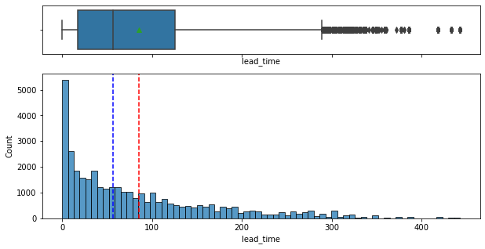

```python
box_hist(df, "lead_time")
```

> Average price per room (average price per day of reservation)

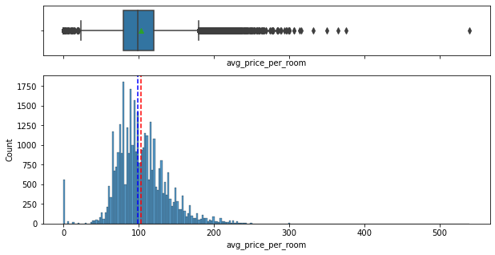

```python
box_hist(df, 'avg_price_per_room')
```

> Number of previous cancellations (number of previous cancellation)

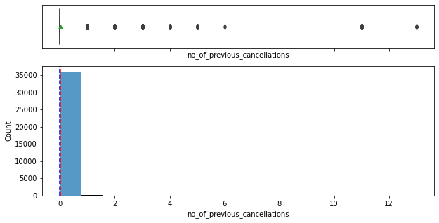

```python
box_hist(df, 'no_of_previous_cancellations')
```

```python
perc=df['no_of_previous_cancellations'].value_counts()*100/36275
# For bookings that are cancelled >>
#Except for '0', therefore
print("Percentage of bookings canceled", (100-perc[0]),"%")
# Percentage of bookings cancelled is 0.93%
```

```
Percentage of bookings canceled 0.9317711922811895 %
```

> Number of previous books not cancelled

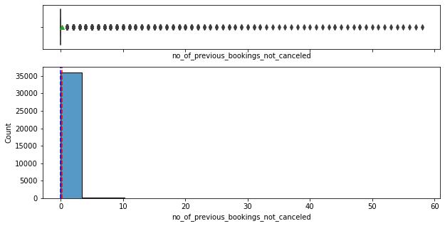

```python
box_hist(df, 'no_of_previous_bookings_not_canceled')
```

> Number of adults

```
2    26108
1     7695
3     2317
0      139
4       16
Name: no_of_adults, dtype: int64
```

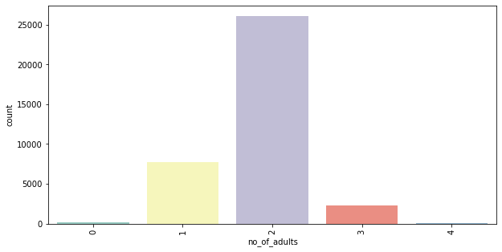

```python
plt.figure(figsize=(10,5))
sns.countplot(data=df, x='no_of_adults', palette="Set3")
plt.xticks(rotation=90);
df['no_of_adults'].value_counts()
```

> Number of children

```
0     33577
1      1618
2      1058
3        19
9         2
10        1
Name: no_of_children, dtype: int64
```

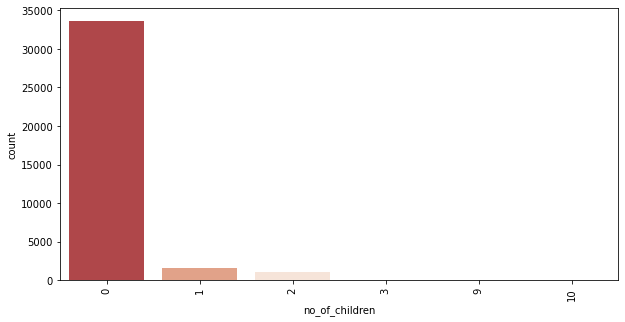

```python
plt.figure(figsize=(10,5))
sns.countplot(data=df, x='no_of_children', palette="RdBu")
plt.xticks(rotation=90);
df['no_of_children'].value_counts()
```

> Number of weekend nights

```
0    16872
1     9995
2     9071
3      153
4      129
5       34
6       20
7        1
Name: no_of_weekend_nights, dtype: int64
```

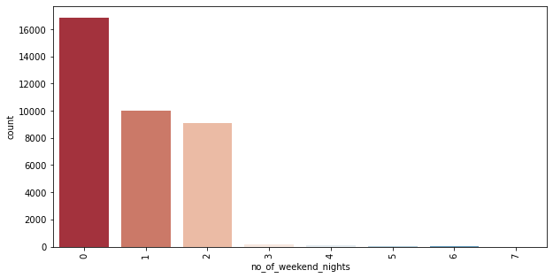

```python
plt.figure(figsize=(10,5))
sns.countplot(data=df, x='no_of_weekend_nights', palette="RdBu")
plt.xticks(rotation=90);
df['no_of_weekend_nights'].value_counts()
```

> Number of week nights

```
2     11444
1      9488
3      7839
4      2990
0      2387
5      1614
6       189
7       113
10       62
8        62
9        34
11       17
15       10
12        9
14        7
13        5
17        3
16        2
Name: no_of_week_nights, dtype: int64
```

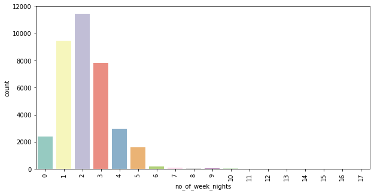

```python
plt.figure(figsize=(10,5))
sns.countplot(data=df, x='no_of_week_nights', palette="Set3")
plt.xticks(rotation=90);
df['no_of_week_nights'].value_counts()
```

> Type of meal plan

```
Meal Plan 1     27835
Not Selected     5130
Meal Plan 2      3305
Meal Plan 3         5
Name: type_of_meal_plan, dtype: int64
```

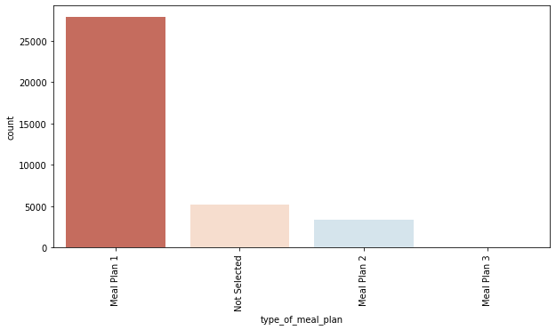

```python
plt.figure(figsize=(10,5))
sns.countplot(data=df, x='type_of_meal_plan', palette="RdBu")
plt.xticks(rotation=90);
df['type_of_meal_plan'].value_counts()
```

> Required car parking space

```
0    35151
1     1124
Name: required_car_parking_space, dtype: int64
```

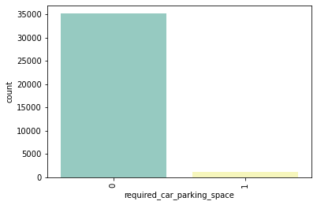

```python
sns.countplot(data=df, x='required_car_parking_space', palette="Set3")
plt.xticks(rotation=90);
df['required_car_parking_space'].value_counts()
```

> Room type reserved

```
Room_Type 1    28130
Room_Type 4     6057
Room_Type 6      966
Room_Type 2      692
Room_Type 5      265
Room_Type 7      158
Room_Type 3        7
Name: room_type_reserved, dtype: int64
```

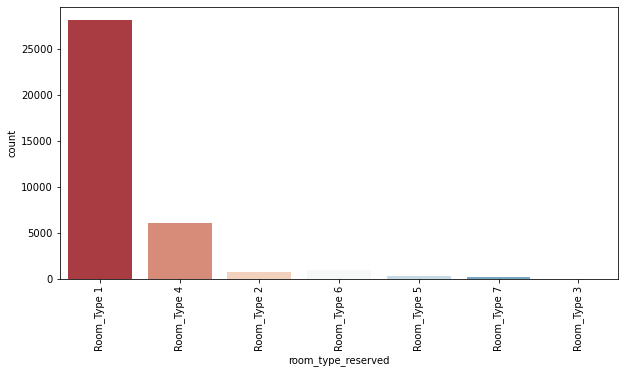

```python
plt.figure(figsize=(10,5))
sns.countplot(data=df, x='room_type_reserved', palette="RdBu")
plt.xticks(rotation=90);
df['room_type_reserved'].value_counts()
```

> Arrival year

```
2018    29761
2017     6514
Name: arrival_year, dtype: int64
```

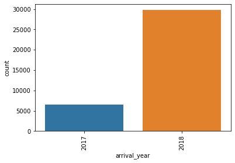

```python
sns.countplot(data=df, x='arrival_year')
plt.xticks(rotation=90);
df['arrival_year'].value_counts()
```

> Arrival month

```
10    5317
9     4611
8     3813
6     3203
12    3021
11    2980
7     2920
4     2736
5     2598
3     2358
2     1704
1     1014
Name: arrival_month, dtype: int64
```

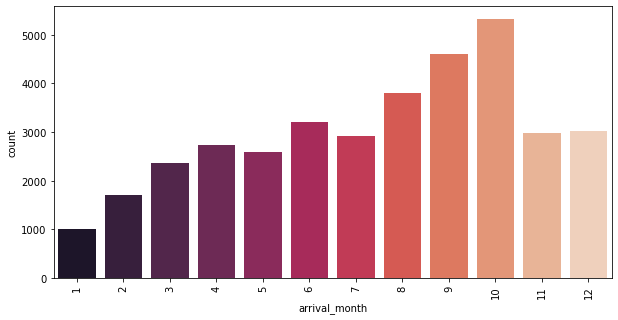

```python
plt.figure(figsize=(10,5))
sns.countplot(data=df, x='arrival_month', palette="rocket")
plt.xticks(rotation=90);
df['arrival_month'].value_counts()
# October has the most booking, with January with the less booking
```

> Arrival date

```
13    1358
17    1345
2     1331
4     1327
19    1327
16    1306
20    1281
15    1273
6     1273
18    1260
14    1242
30    1216
12    1204
8     1198
29    1190
```

[output cut: 17 more lines]

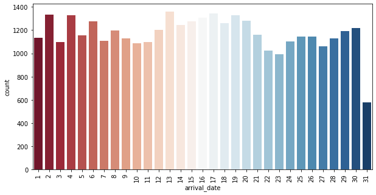

```python
plt.figure(figsize=(10,5))
sns.countplot(data=df, x='arrival_date', palette="RdBu")
plt.xticks(rotation=90);
df['arrival_date'].value_counts()
```

> Market segment type

```
Online           23214
Offline          10528
Corporate         2017
Complementary      391
Aviation           125
Name: market_segment_type, dtype: int64
```

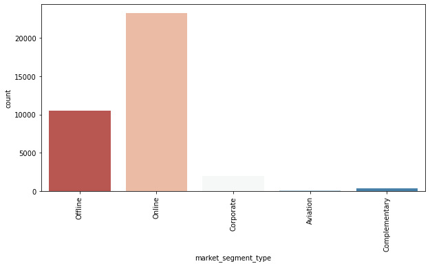

```python
plt.figure(figsize=(10,5))
sns.countplot(data=df, x='market_segment_type', palette="RdBu")
plt.xticks(rotation=90);
df['market_segment_type'].value_counts()
# 'Online' market segment designation has the most booking, with aviation as the most least
```

> Repeated guest

```
0    35345
1      930
Name: repeated_guest, dtype: int64
```

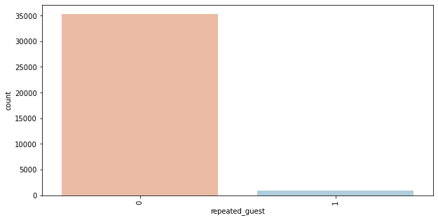

```python
plt.figure(figsize=(10,5))
sns.countplot(data=df, x='repeated_guest', palette="RdBu")
plt.xticks(rotation=90);
df['repeated_guest'].value_counts()
```

> Number of special requests

```
0    19777
1    11373
2     4364
3      675
4       78
5        8
Name: no_of_special_requests, dtype: int64
```

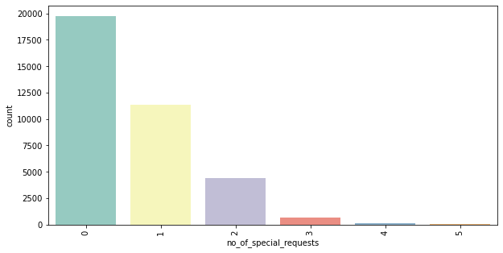

```python
plt.figure(figsize=(10,5))
sns.countplot(data=df, x='no_of_special_requests', palette="Set3")
plt.xticks(rotation=90);
df['no_of_special_requests'].value_counts()
```

### Bivariate

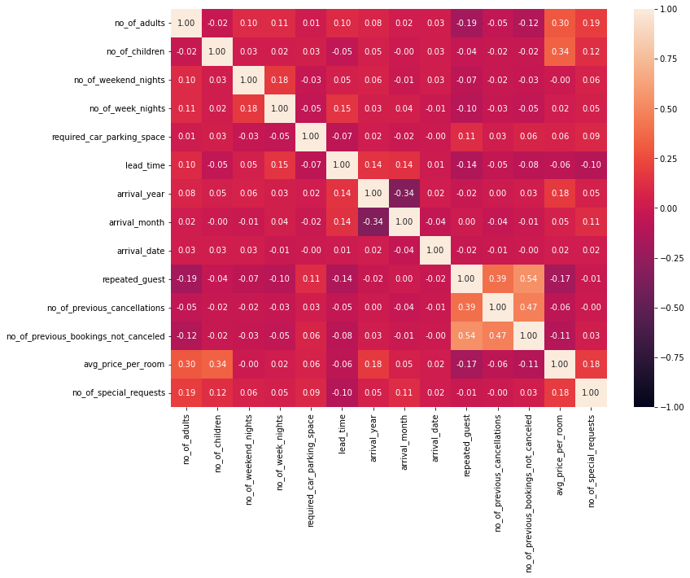

```python
# Let's make a heatmap
list = data.select_dtypes(include=np.number).columns.tolist()
plt.figure(figsize=(12,9))
sns.heatmap(data[list].corr(),annot=True, vmin=-1, vmax=1, fmt=".2f");
```

```python
df.head().T
```

|  | 0 | 1 | 2 | 3 | 4 |
| --- | --- | --- | --- | --- | --- |
| Booking_ID | INN00001 | INN00002 | INN00003 | INN00004 | INN00005 |
| no_of_adults | 2 | 2 | 1 | 2 | 2 |
| no_of_children | 0 | 0 | 0 | 0 | 0 |
| no_of_weekend_nights | 1 | 2 | 2 | 0 | 1 |
| no_of_week_nights | 2 | 3 | 1 | 2 | 1 |
| type_of_meal_plan | Meal Plan 1 | Not Selected | Meal Plan 1 | Meal Plan 1 | Not Selected |
| required_car_parking_space | 0 | 0 | 0 | 0 | 0 |
| room_type_reserved | Room_Type 1 | Room_Type 1 | Room_Type 1 | Room_Type 1 | Room_Type 1 |
| lead_time | 224 | 5 | 1 | 211 | 48 |
| arrival_year | 2017 | 2018 | 2018 | 2018 | 2018 |
| arrival_month | 10 | 11 | 2 | 5 | 4 |
| arrival_date | 2 | 6 | 28 | 20 | 11 |
| market_segment_type | Offline | Online | Online | Online | Online |
| repeated_guest | 0 | 0 | 0 | 0 | 0 |
| no_of_previous_cancellations | 0 | 0 | 0 | 0 | 0 |
| no_of_previous_bookings_not_canceled | 0 | 0 | 0 | 0 | 0 |
| avg_price_per_room | 65.0 | 106.68 | 60.0 | 100.0 | 94.5 |
| no_of_special_requests | 0 | 1 | 0 | 0 | 0 |
| booking_status | Not_Canceled | Not_Canceled | Canceled | Canceled | Canceled |

Average price per room of reservations vs market segment type

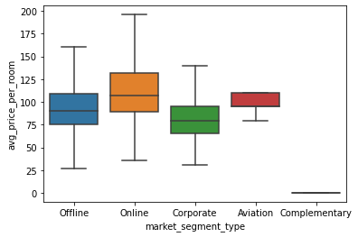

```python
sns.boxplot(data=df, x='market_segment_type', y='avg_price_per_room', showfliers=False);
# Average price median is highest for Aviation and Online
# While, complementary is the lowest price
# However, Online platform has the widest scope/range for price
```

Market segment type vs booking status

```python
table=pd.crosstab(df['market_segment_type'], df['booking_status'], margins=True)
```

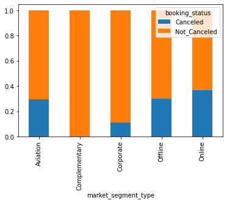

```python
table1=pd.crosstab(df['market_segment_type'], df['booking_status'], normalize='index')
table1
plt.figure(figsize=(10,8));
table1.plot(kind="bar", stacked=True);
# Complementary segment has less customers cancelling
# Online segment has most customers cancelling
```

Special request impact on cancellations

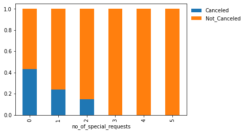

```python
table2=pd.crosstab(df['no_of_special_requests'], df['booking_status'], normalize='index')
table2
plt.figure(figsize=(15,10))
table2.plot(kind="bar", stacked='True')
plt.legend(loc='upper left', frameon=False, bbox_to_anchor=(1,1));
# Booking is less canceled, when there are more number of special requests
# Therefore, people cancel less when there are more number of special requests
```

Special request impact on price of room

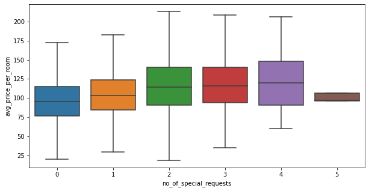

```python
plt.figure(figsize=(10,5))
sns.boxplot(data=df, x='no_of_special_requests', y='avg_price_per_room', showfliers=False);
# On average, 2~4 number of special requests median is similar in terms of price of rom
# Price of room is higher for those making special requests, on average
```

Booking status vs average price per room

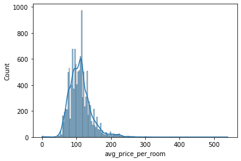

```python
la=df[df['booking_status']=="Canceled"]
la_=df[df['booking_status']=='Not_Canceled']
# For booking status canceled
sns.histplot(data=la, x='avg_price_per_room', kde=True);
# For canceled booking status,
# Right-skewed in terms of average price of room
```

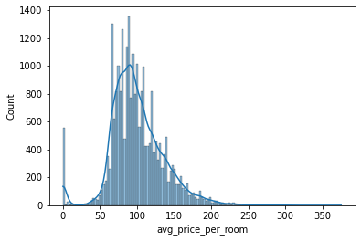

```python
# For booking status not canceled
sns.histplot(data=la_, x='avg_price_per_room', kde=True);
# For not canceled,
# The graph is also slightly right-skewed in terms of average price of room
```

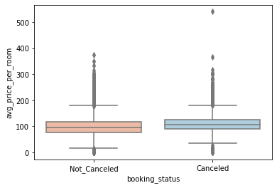

```python
sns.boxplot(data=df, x='booking_status', y='avg_price_per_room', palette='RdBu');
# The median average price is slightly higher for canceled
```

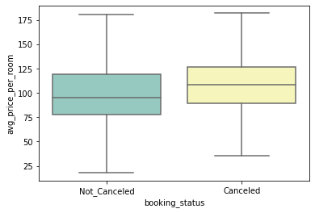

```python
# Look without outliers
sns.boxplot(data=df, x='booking_status', y='avg_price_per_room', showfliers=False, palette='Set3');
# The median average price is slightly higher for canceled
# However, the range for each booking status is simlar
```

Booking status vs lead time

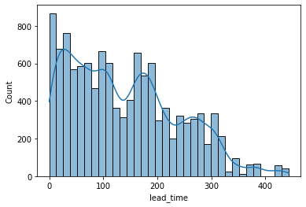

```python
la=df[df['booking_status']=="Canceled"]
la_=df[df['booking_status']=='Not_Canceled']
# For booking status canceled
sns.histplot(data=la, x='lead_time', kde=True);
```